# Entrega 3 Julia y Fernanda

[figure not shown]

[figure not shown]

[figure not shown]

[figure not shown]

[figure not shown]

[figure not shown]

[figure not shown]

[figure not shown]

[figure not shown]

[figure not shown]

# Exploración de la base

## Column {data-width=500}

### Gráfico de densidad

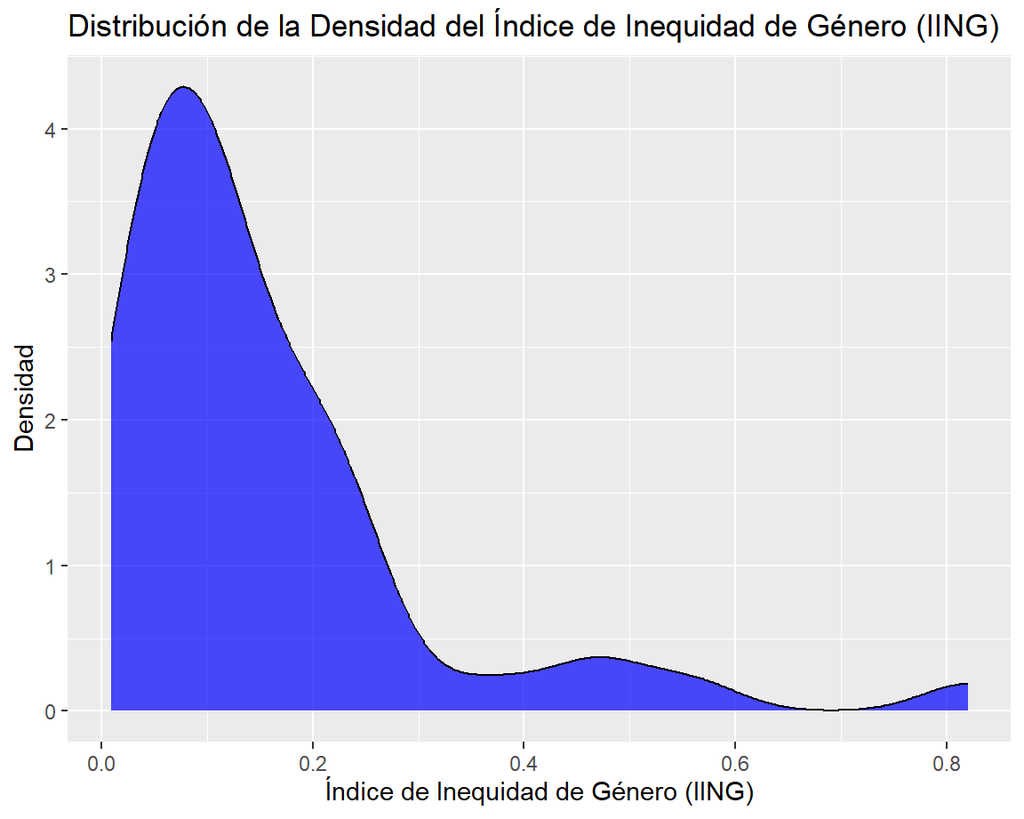

### Matriz de correlaciones

|  | PM | PIB | FLT | EVN | DT |
| --- | --- | --- | --- | --- | --- |
| 1 | 50.1 | 6.1 | 50.57953 | 76.83300 | 11.3 |
| 2 | 50.8 | 3.8 | 52.66603 | 81.09268 | 4.9 |
| 3 | 50.6 | 2.1 | 45.98998 | 81.69756 | 5.5 |
| 4 | 51.5 | 10.6 | 48.67831 | 74.36098 | 4.2 |
| 5 | 50.8 | 5.4 | 42.72710 | 75.29300 | 12.6 |
| 6 | 54.0 | -3.9 | 54.11234 | 73.11146 | 3.5 |
| 7 | 50.3 | 1.7 | 56.61302 | 83.45366 | 4.1 |
| 8 | 50.4 | 6.0 | 393.46561 | 81.88900 | 6.8 |
| 9 | 50.5 | 5.6 | 27.40713 | 79.02927 | 2.2 |
| 10 | 50.0 | 2.5 | 3.12979 | 80.70561 | 3.1 |

> Estos datos reflejan las condiciones de vida y oportunidades en cada país. Por ejemplo, Suiza destaca por su alta esperanza de vida (83.4 años) y bajo desempleo (4.1%), mientras que Bosnia y Herzegovina enfrenta desafíos con un desempleo del 12.6%. Estas variables permiten explorar cómo factores económicos y demográficos influyen en las disparidades de género, incluso cuando estas no están explícitas en las columnas seleccionadas.

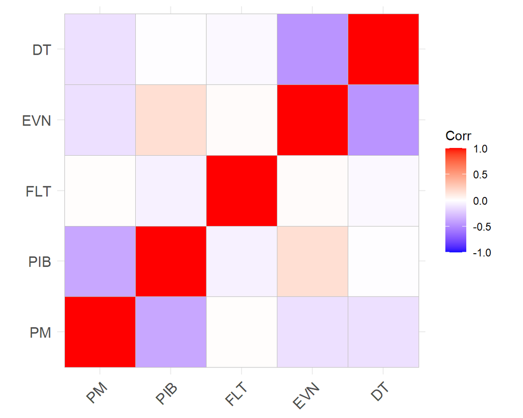

Column {data-width=200}

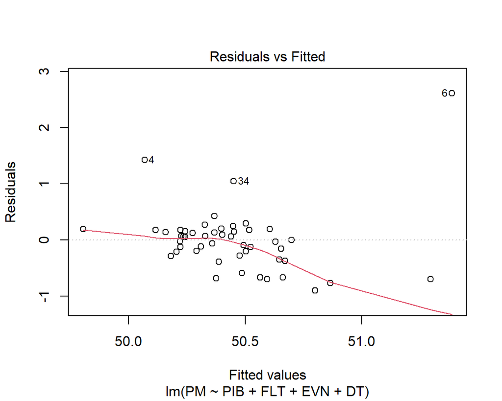

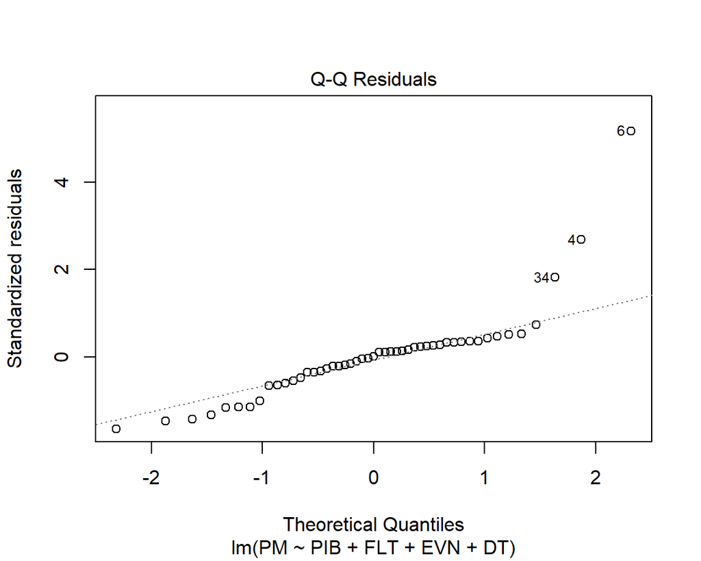

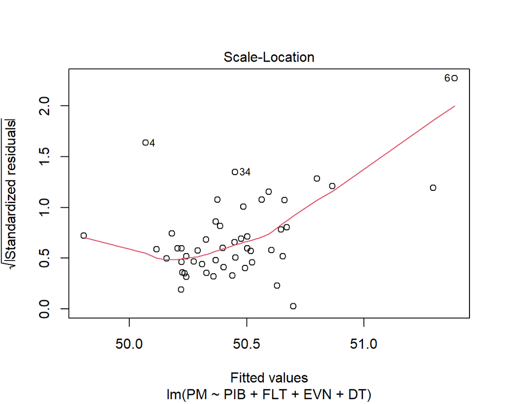

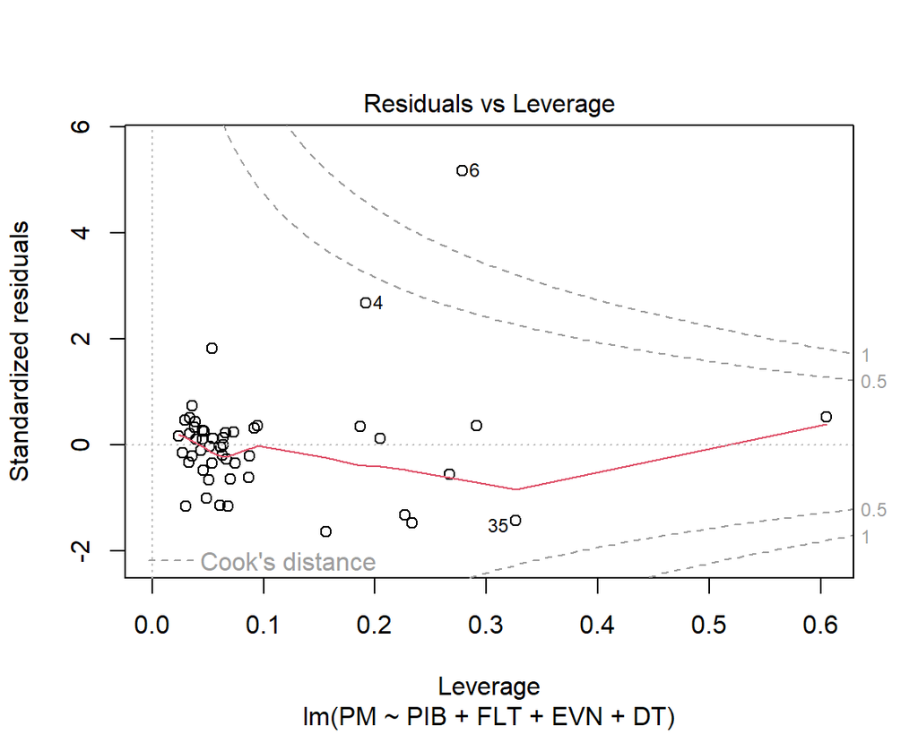

```
     PIB      FLT      EVN       DT
1.041437 1.005659 1.317439 1.278973
```

> Todos los valores de VIF están por debajo de 5, lo que indica que no hay problemas de multicolinealidad significativa entre las variables independientes.

```
Kaiser-Meyer-Olkin factor adequacy
Call: psych::KMO(r = corMatrix)
Overall MSA =  0.49
MSA for each item =
  PM  PIB  FLT  EVN   DT
0.48 0.55 0.49 0.49 0.46
```

> Resultado es 0.49, lo que está por debajo del umbral mínimo de 0.6 para considerar los datos como aceptables para el análisis factorial. Esto indica una baja correlación parcial entre las variables, lo cual significa que no tienen suficiente relación para formar factores significativos.

# Sacamos la variable PM

|  | IING | PIB | FLT | EVN | DT |
| --- | --- | --- | --- | --- | --- |
| 1 | 0.116 | 6.1 | 50.57953 | 76.83300 | 11.3 |
| 2 | 0.048 | 3.8 | 52.66603 | 81.09268 | 4.9 |
| 3 | 0.044 | 2.1 | 45.98998 | 81.69756 | 5.5 |
| 4 | 0.206 | 10.6 | 48.67831 | 74.36098 | 4.2 |
| 5 | 0.148 | 5.4 | 42.72710 | 75.29300 | 12.6 |
| 6 | 0.096 | -3.9 | 54.11234 | 73.11146 | 3.5 |
| 7 | 0.018 | 1.7 | 56.61302 | 83.45366 | 4.1 |
| 8 | 0.253 | 6.0 | 393.46561 | 81.88900 | 6.8 |
| 9 | 0.113 | 5.6 | 27.40713 | 79.02927 | 2.2 |
| 10 | 0.071 | 2.5 | 3.12979 | 80.70561 | 3.1 |

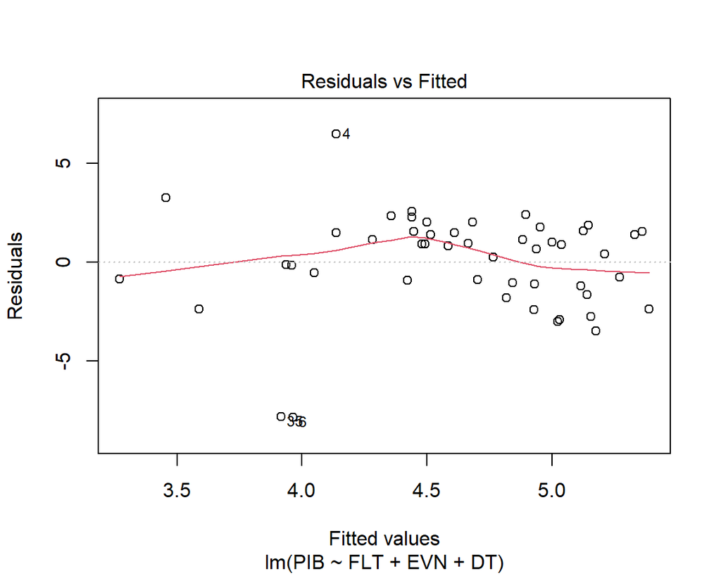

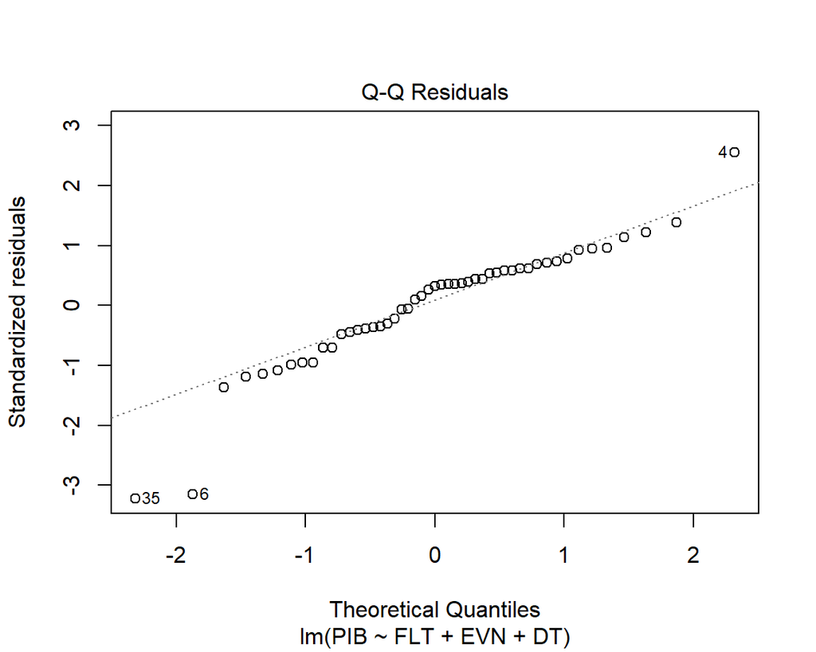

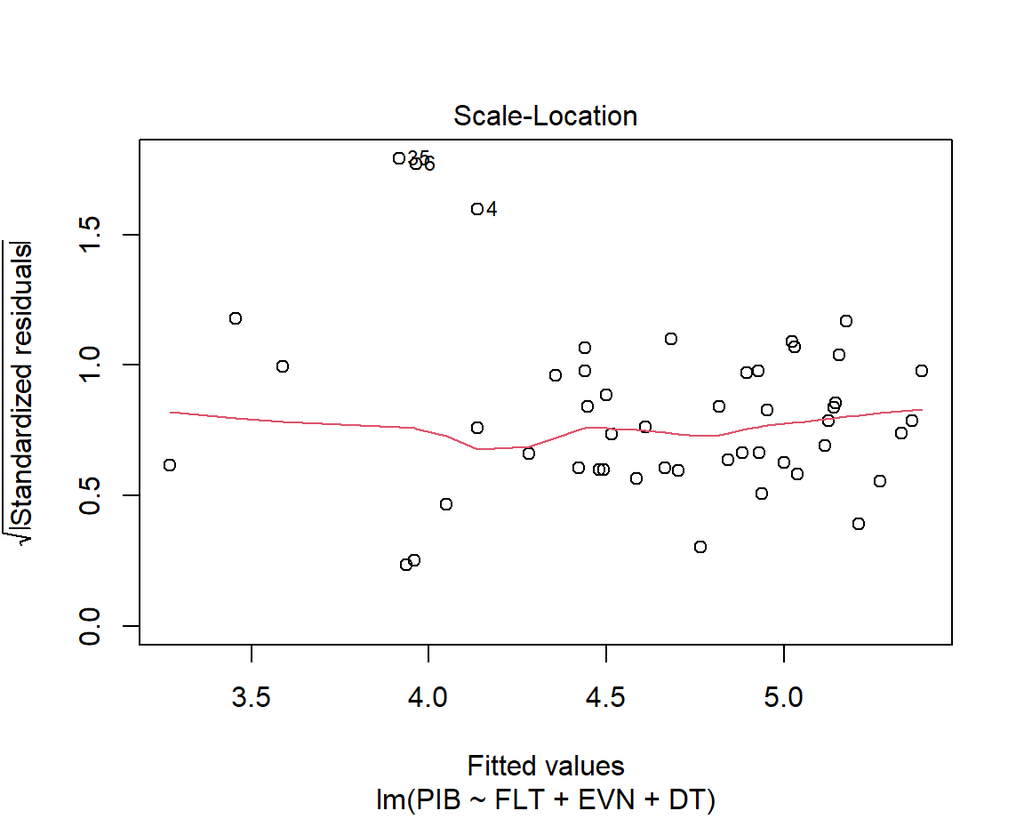

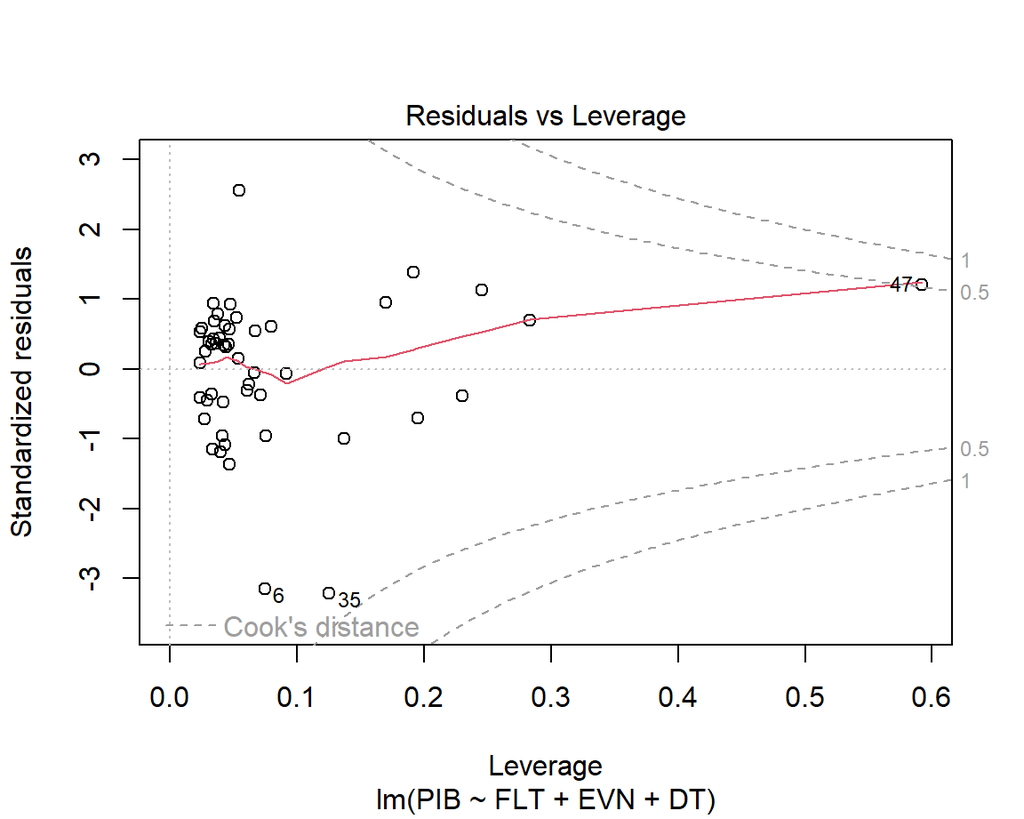

```
     FLT      EVN       DT
1.001071 1.270590 1.271429
```

```
Kaiser-Meyer-Olkin factor adequacy
Call: psych::KMO(r = corMatrix2)
Overall MSA =  0.64
MSA for each item =
IING  PIB  FLT  EVN   DT
0.60 0.50 0.40 0.62 0.80
```

# Sacamos la variable DT

|  | IING | PM | PIB | FLT | EVN |
| --- | --- | --- | --- | --- | --- |
| 1 | 0.116 | 50.1 | 6.1 | 50.57953 | 76.83300 |
| 2 | 0.048 | 50.8 | 3.8 | 52.66603 | 81.09268 |
| 3 | 0.044 | 50.6 | 2.1 | 45.98998 | 81.69756 |
| 4 | 0.206 | 51.5 | 10.6 | 48.67831 | 74.36098 |
| 5 | 0.148 | 50.8 | 5.4 | 42.72710 | 75.29300 |
| 6 | 0.096 | 54.0 | -3.9 | 54.11234 | 73.11146 |
| 7 | 0.018 | 50.3 | 1.7 | 56.61302 | 83.45366 |
| 8 | 0.253 | 50.4 | 6.0 | 393.46561 | 81.88900 |
| 9 | 0.113 | 50.5 | 5.6 | 27.40713 | 79.02927 |
| 10 | 0.071 | 50.0 | 2.5 | 3.12979 | 80.70561 |

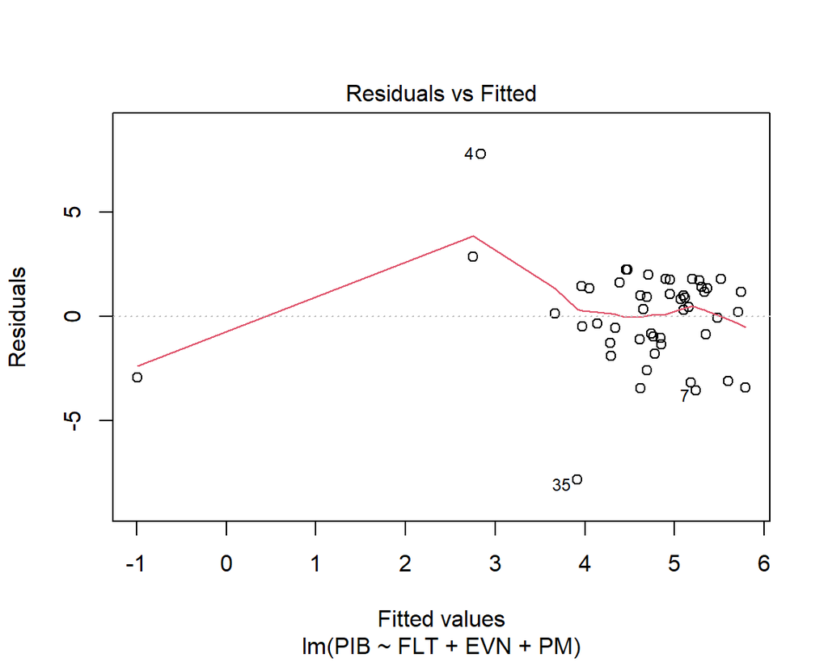

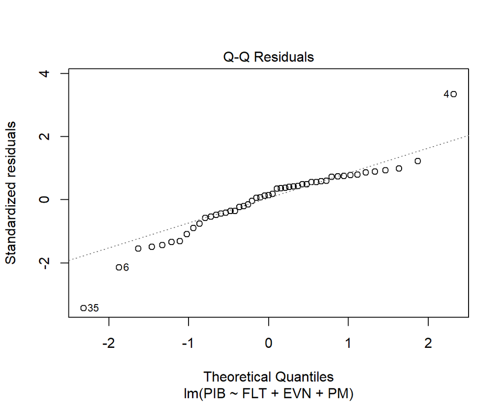

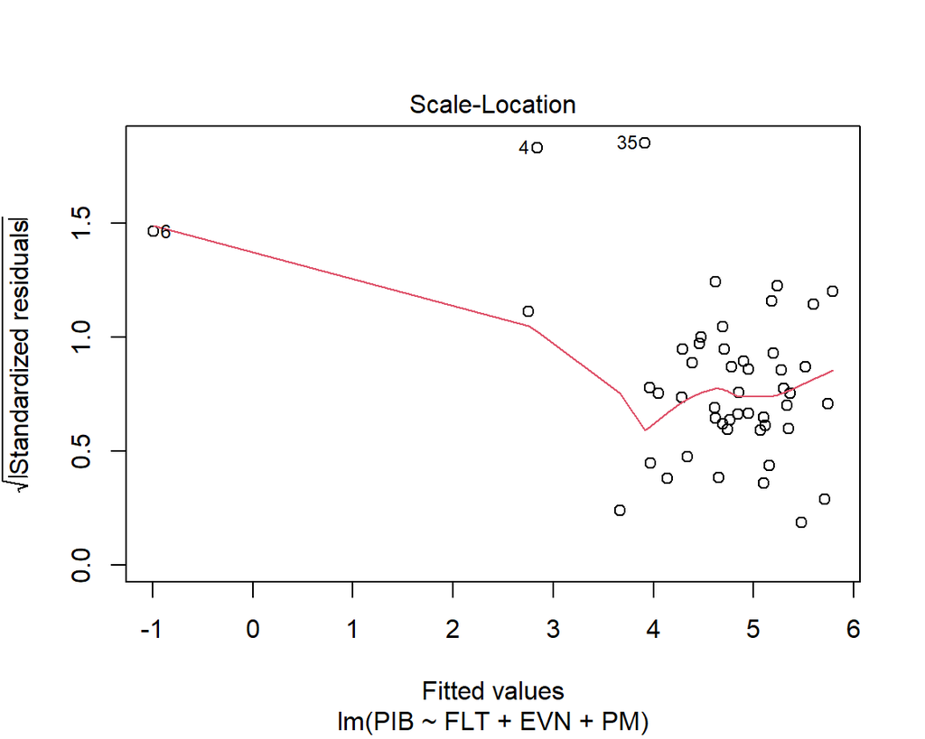

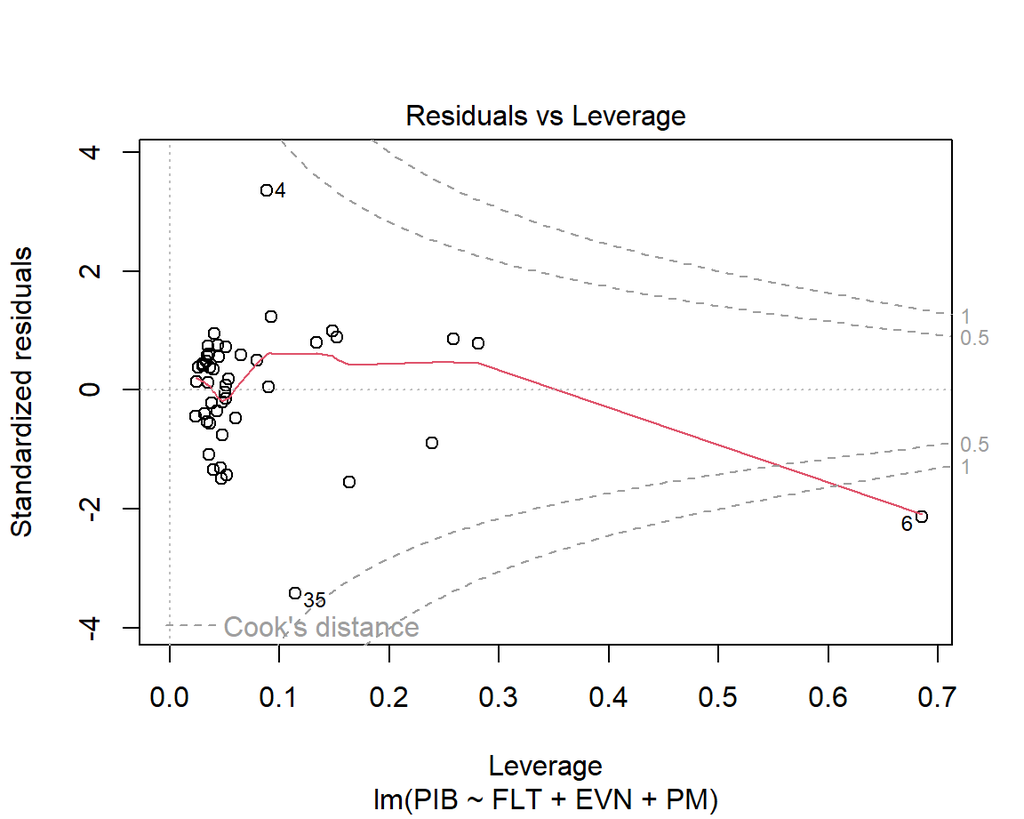

```
     FLT      EVN       PM
1.000561 1.018388 1.018114
```

```
Kaiser-Meyer-Olkin factor adequacy
Call: psych::KMO(r = corMatrix3)
Overall MSA =  0.45
MSA for each item =
IING   PM  PIB  FLT  EVN
0.44 0.33 0.56 0.42 0.46
```

# Cluster

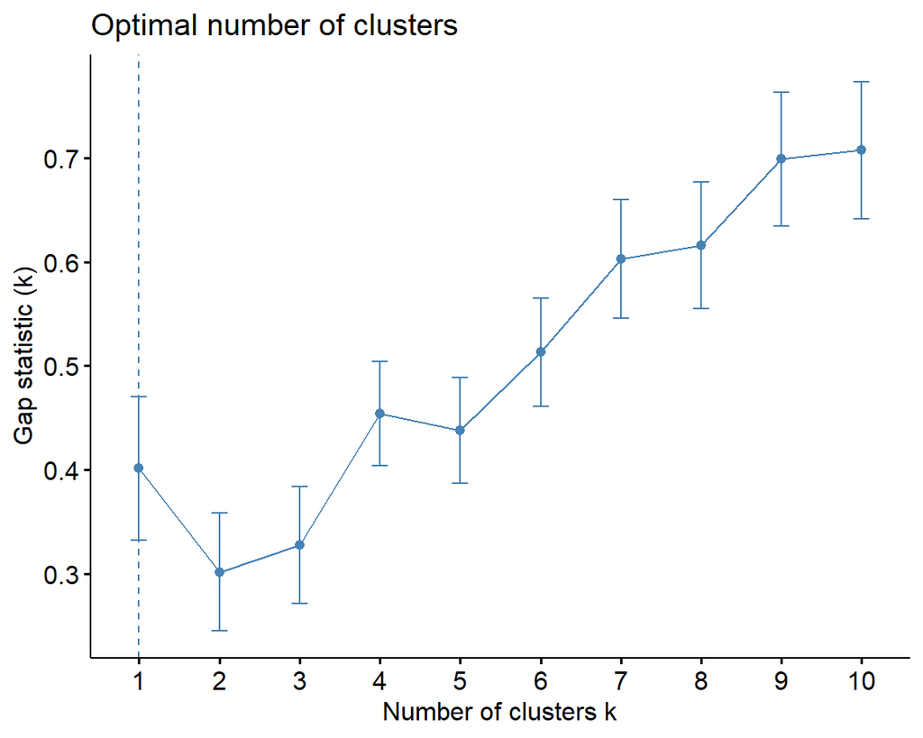

Column {data-width=330}

|  | PM | PIB | FLT | EVN | DT | pam |
| --- | --- | --- | --- | --- | --- | --- |
| Albania | 50.1 | 6.1 | 50.5795285 | 76.83300 | 11.30 | 1 |
| Austria | 50.8 | 3.8 | 52.6660304 | 81.09268 | 4.90 | 1 |
| Bélgica | 50.6 | 2.1 | 45.9899755 | 81.69756 | 5.50 | 1 |
| Bulgaria | 51.5 | 10.6 | 48.6783106 | 74.36098 | 4.20 | 1 |
| Bosnia y Herzegovina | 50.8 | 5.4 | 42.7271035 | 75.29300 | 12.60 | 1 |
| Bielorrusia | 54.0 | -3.9 | 54.1123383 | 73.11146 | 3.50 | 1 |
| Suiza | 50.3 | 1.7 | 56.6130227 | 83.45366 | 4.10 | 1 |
| Chipre | 50.4 | 6.0 | 393.4656104 | 81.88900 | 6.80 | 1 |
| República Checa | 50.5 | 5.6 | 27.4071321 | 79.02927 | 2.20 | 1 |
| Alemania | 50.0 | 2.5 | 3.1297895 | 80.70561 | 3.10 | 1 |
| Dinamarca | 50.3 | 2.0 | 8.0676994 | 81.30488 | 4.40 | 1 |
| España | 50.6 | 3.0 | 45.6630721 | 83.08293 | 12.90 | 1 |
| Estonia | 49.7 | 5.9 | 87.7756718 | 77.94390 | 5.50 | 1 |
| Finlandia | 50.4 | 6.0 | 54.9277731 | 81.30488 | 6.70 | 1 |
| Francia | 50.6 | 3.9 | 6.8039512 | 81.39799 | 7.30 | 1 |
| Reino Unido | 49.9 | 7.0 | 368.5689180 | 82.14300 | 3.70 | 1 |
| Grecia | 50.2 | 4.5 | 10.0607897 | 81.62273 | 12.40 | 1 |
| Croacia | 50.4 | 3.8 | 62.3097758 | 80.03659 | 6.90 | 1 |
| Hungría | 49.9 | 5.4 | 2.9114064 | 76.83300 | 3.60 | 1 |
| Irlanda | 50.8 | 3.0 | 41.3510888 | 80.03939 | 4.50 | 1 |
| Islandia | 50.2 | 6.7 | 56.4334218 | 83.10800 | 3.70 | 1 |
| Italia | 49.9 | 2.4 | 14.8040207 | 81.69200 | 8.06 | 1 |
| Kazajistán | 50.5 | 3.8 | 146.7503117 | 74.05400 | 4.80 | 1 |
| Letonia | 50.0 | 7.3 | 0.5664137 | 79.52600 | 6.80 | 1 |
| Luxemburgo | 50.3 | 6.7 | 83.5850984 | 85.12200 | 4.50 | 1 |
| Lituania | 50.5 | 5.0 | 87.9647413 | 79.99154 | 5.90 | 1 |
| Moldavia | 49.9 | 6.7 | 26.6321321 | 68.92700 | 0.80 | 1 |
| Macedonia del Norte | 50.7 | 3.8 | 201.1920389 | 72.89600 | 14.40 | 1 |
| Montenegro | 50.3 | 6.7 | 301.0476190 | 78.53200 | 14.80 | 1 |
| Países Bajos | 50.4 | 6.7 | 83.8091210 | 82.10500 | 3.50 | 1 |
| Noruega | 50.4 | 5.6 | 10.6796796 | 83.22200 | 3.20 | 1 |
| Polonia | 50.2 | 5.4 | 3.9383540 | 77.82354 | 2.80 | 1 |
| Portugal | 50.6 | 5.6 | 59.6441739 | 81.01900 | 6.01 | 1 |
| Rumanía | 51.5 | 5.6 | 141.1045213 | 75.50274 | 5.60 | 1 |
| Rusia | 50.6 | -3.9 | 262.0642103 | 75.93312 | 3.80 | 1 |
| Serbia | 50.7 | 5.4 | 56.4913480 | 74.76300 | 8.40 | 1 |
| Eslovaquia | 50.5 | 6.7 | 5.4261088 | 75.12800 | 6.10 | 1 |
| Eslovenia | 50.4 | 3.8 | 126.1889112 | 80.50500 | 4.01 | 1 |
| Suecia | 50.3 | 5.9 | 110.4803691 | 82.37300 | 7.30 | 1 |
| Arabia Saudita | 50.7 | 3.5 | 43.5073880 | 73.23600 | 5.50 | 1 |
| Irak | 49.9 | 1.2 | 190.2111475 | 69.04800 | 16.60 | 1 |
| Jordania | 50.3 | 3.5 | 5.8007800 | 72.92200 | 18.20 | 1 |
| Kuwait | 50.0 | 6.5 | 40.5586772 | 77.84700 | 2.10 | 1 |
| Libano | 50.3 | 3.5 | 3.4951193 | 76.45500 | 29.60 | 1 |
| Oman | 50.3 | 6.0 | 4.3587384 | 80.27700 | 3.30 | 1 |
| Qatar | 50.1 | 6.9 | 3.8767766 | 85.12200 | 0.13 | 1 |
| Siria | 50.0 | 6.7 | 11.2120105 | 67.83500 | 50.50 | 1 |
| Emiratos Arabes Unidos | 50.3 | 7.0 | 1.4278501 | 82.61800 | 2.80 | 1 |
| Yemen | 50.1 | 2.4 | 12.8445867 | 63.99300 | 14.40 | 1 |

```
character(0)
```

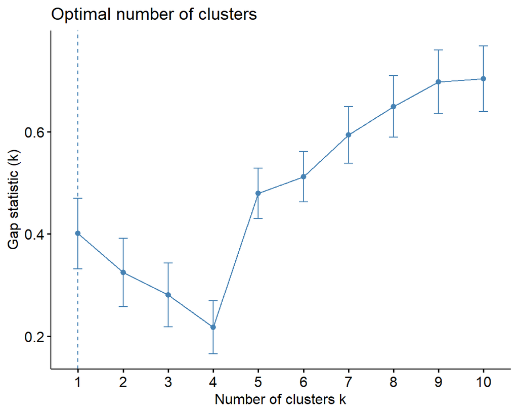

|  | PM | PIB | FLT | EVN | DT | pam | agnes |
| --- | --- | --- | --- | --- | --- | --- | --- |
| Albania | 50.1 | 6.1 | 50.5795285 | 76.83300 | 11.30 | 1 | 1 |
| Austria | 50.8 | 3.8 | 52.6660304 | 81.09268 | 4.90 | 1 | 1 |
| Bélgica | 50.6 | 2.1 | 45.9899755 | 81.69756 | 5.50 | 1 | 1 |
| Bulgaria | 51.5 | 10.6 | 48.6783106 | 74.36098 | 4.20 | 1 | 1 |
| Bosnia y Herzegovina | 50.8 | 5.4 | 42.7271035 | 75.29300 | 12.60 | 1 | 1 |
| Bielorrusia | 54.0 | -3.9 | 54.1123383 | 73.11146 | 3.50 | 1 | 1 |
| Suiza | 50.3 | 1.7 | 56.6130227 | 83.45366 | 4.10 | 1 | 1 |
| Chipre | 50.4 | 6.0 | 393.4656104 | 81.88900 | 6.80 | 1 | 1 |
| República Checa | 50.5 | 5.6 | 27.4071321 | 79.02927 | 2.20 | 1 | 1 |
| Alemania | 50.0 | 2.5 | 3.1297895 | 80.70561 | 3.10 | 1 | 1 |
| Dinamarca | 50.3 | 2.0 | 8.0676994 | 81.30488 | 4.40 | 1 | 1 |
| España | 50.6 | 3.0 | 45.6630721 | 83.08293 | 12.90 | 1 | 1 |
| Estonia | 49.7 | 5.9 | 87.7756718 | 77.94390 | 5.50 | 1 | 1 |
| Finlandia | 50.4 | 6.0 | 54.9277731 | 81.30488 | 6.70 | 1 | 1 |
| Francia | 50.6 | 3.9 | 6.8039512 | 81.39799 | 7.30 | 1 | 1 |
| Reino Unido | 49.9 | 7.0 | 368.5689180 | 82.14300 | 3.70 | 1 | 1 |
| Grecia | 50.2 | 4.5 | 10.0607897 | 81.62273 | 12.40 | 1 | 1 |
| Croacia | 50.4 | 3.8 | 62.3097758 | 80.03659 | 6.90 | 1 | 1 |
| Hungría | 49.9 | 5.4 | 2.9114064 | 76.83300 | 3.60 | 1 | 1 |
| Irlanda | 50.8 | 3.0 | 41.3510888 | 80.03939 | 4.50 | 1 | 1 |
| Islandia | 50.2 | 6.7 | 56.4334218 | 83.10800 | 3.70 | 1 | 1 |
| Italia | 49.9 | 2.4 | 14.8040207 | 81.69200 | 8.06 | 1 | 1 |
| Kazajistán | 50.5 | 3.8 | 146.7503117 | 74.05400 | 4.80 | 1 | 1 |
| Letonia | 50.0 | 7.3 | 0.5664137 | 79.52600 | 6.80 | 1 | 1 |
| Luxemburgo | 50.3 | 6.7 | 83.5850984 | 85.12200 | 4.50 | 1 | 1 |
| Lituania | 50.5 | 5.0 | 87.9647413 | 79.99154 | 5.90 | 1 | 1 |
| Moldavia | 49.9 | 6.7 | 26.6321321 | 68.92700 | 0.80 | 1 | 1 |
| Macedonia del Norte | 50.7 | 3.8 | 201.1920389 | 72.89600 | 14.40 | 1 | 1 |
| Montenegro | 50.3 | 6.7 | 301.0476190 | 78.53200 | 14.80 | 1 | 1 |
| Países Bajos | 50.4 | 6.7 | 83.8091210 | 82.10500 | 3.50 | 1 | 1 |
| Noruega | 50.4 | 5.6 | 10.6796796 | 83.22200 | 3.20 | 1 | 1 |
| Polonia | 50.2 | 5.4 | 3.9383540 | 77.82354 | 2.80 | 1 | 1 |
| Portugal | 50.6 | 5.6 | 59.6441739 | 81.01900 | 6.01 | 1 | 1 |
| Rumanía | 51.5 | 5.6 | 141.1045213 | 75.50274 | 5.60 | 1 | 1 |
| Rusia | 50.6 | -3.9 | 262.0642103 | 75.93312 | 3.80 | 1 | 1 |
| Serbia | 50.7 | 5.4 | 56.4913480 | 74.76300 | 8.40 | 1 | 1 |
| Eslovaquia | 50.5 | 6.7 | 5.4261088 | 75.12800 | 6.10 | 1 | 1 |
| Eslovenia | 50.4 | 3.8 | 126.1889112 | 80.50500 | 4.01 | 1 | 1 |
| Suecia | 50.3 | 5.9 | 110.4803691 | 82.37300 | 7.30 | 1 | 1 |
| Arabia Saudita | 50.7 | 3.5 | 43.5073880 | 73.23600 | 5.50 | 1 | 1 |
| Irak | 49.9 | 1.2 | 190.2111475 | 69.04800 | 16.60 | 1 | 1 |
| Jordania | 50.3 | 3.5 | 5.8007800 | 72.92200 | 18.20 | 1 | 1 |
| Kuwait | 50.0 | 6.5 | 40.5586772 | 77.84700 | 2.10 | 1 | 1 |
| Libano | 50.3 | 3.5 | 3.4951193 | 76.45500 | 29.60 | 1 | 1 |
| Oman | 50.3 | 6.0 | 4.3587384 | 80.27700 | 3.30 | 1 | 1 |
| Qatar | 50.1 | 6.9 | 3.8767766 | 85.12200 | 0.13 | 1 | 1 |
| Siria | 50.0 | 6.7 | 11.2120105 | 67.83500 | 50.50 | 1 | 1 |
| Emiratos Arabes Unidos | 50.3 | 7.0 | 1.4278501 | 82.61800 | 2.80 | 1 | 1 |
| Yemen | 50.1 | 2.4 | 12.8445867 | 63.99300 | 14.40 | 1 | 1 |

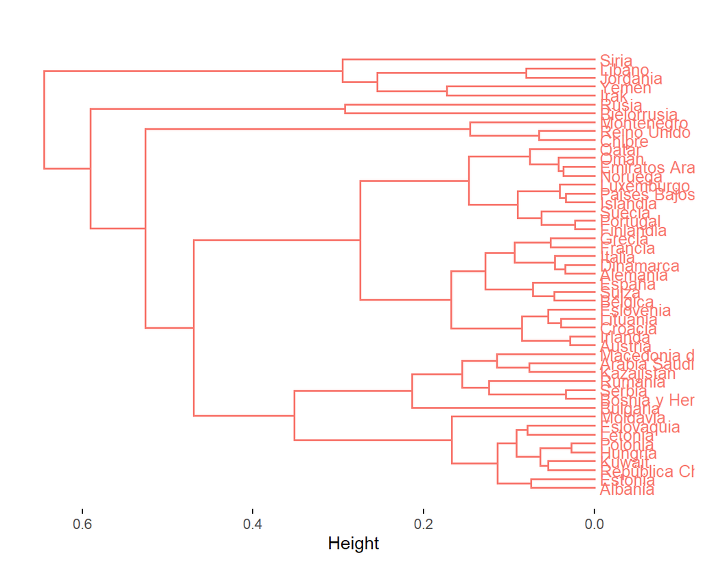

```
character(0)
```

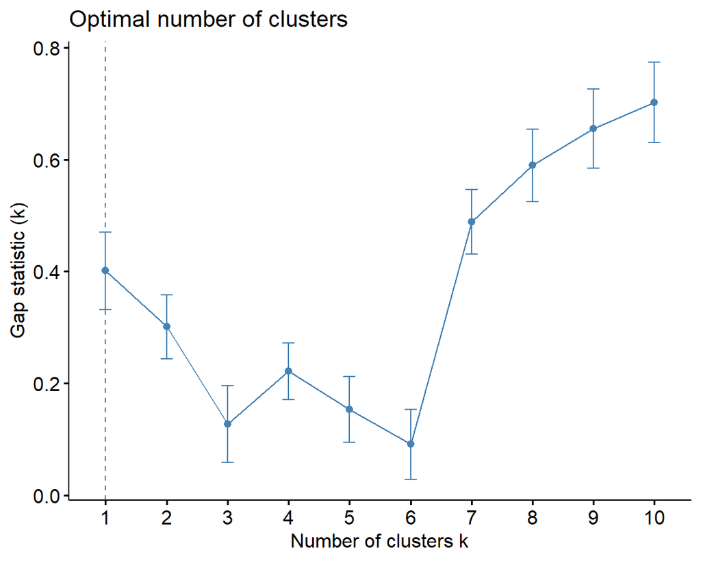

|  | PM | PIB | FLT | EVN | DT | pam | agnes | diana |
| --- | --- | --- | --- | --- | --- | --- | --- | --- |
| Albania | 50.1 | 6.1 | 50.5795285 | 76.83300 | 11.30 | 1 | 1 | 1 |
| Austria | 50.8 | 3.8 | 52.6660304 | 81.09268 | 4.90 | 1 | 1 | 1 |
| Bélgica | 50.6 | 2.1 | 45.9899755 | 81.69756 | 5.50 | 1 | 1 | 1 |
| Bulgaria | 51.5 | 10.6 | 48.6783106 | 74.36098 | 4.20 | 1 | 1 | 1 |
| Bosnia y Herzegovina | 50.8 | 5.4 | 42.7271035 | 75.29300 | 12.60 | 1 | 1 | 1 |
| Bielorrusia | 54.0 | -3.9 | 54.1123383 | 73.11146 | 3.50 | 1 | 1 | 1 |
| Suiza | 50.3 | 1.7 | 56.6130227 | 83.45366 | 4.10 | 1 | 1 | 1 |
| Chipre | 50.4 | 6.0 | 393.4656104 | 81.88900 | 6.80 | 1 | 1 | 1 |
| República Checa | 50.5 | 5.6 | 27.4071321 | 79.02927 | 2.20 | 1 | 1 | 1 |
| Alemania | 50.0 | 2.5 | 3.1297895 | 80.70561 | 3.10 | 1 | 1 | 1 |
| Dinamarca | 50.3 | 2.0 | 8.0676994 | 81.30488 | 4.40 | 1 | 1 | 1 |
| España | 50.6 | 3.0 | 45.6630721 | 83.08293 | 12.90 | 1 | 1 | 1 |
| Estonia | 49.7 | 5.9 | 87.7756718 | 77.94390 | 5.50 | 1 | 1 | 1 |
| Finlandia | 50.4 | 6.0 | 54.9277731 | 81.30488 | 6.70 | 1 | 1 | 1 |
| Francia | 50.6 | 3.9 | 6.8039512 | 81.39799 | 7.30 | 1 | 1 | 1 |
| Reino Unido | 49.9 | 7.0 | 368.5689180 | 82.14300 | 3.70 | 1 | 1 | 1 |
| Grecia | 50.2 | 4.5 | 10.0607897 | 81.62273 | 12.40 | 1 | 1 | 1 |
| Croacia | 50.4 | 3.8 | 62.3097758 | 80.03659 | 6.90 | 1 | 1 | 1 |
| Hungría | 49.9 | 5.4 | 2.9114064 | 76.83300 | 3.60 | 1 | 1 | 1 |
| Irlanda | 50.8 | 3.0 | 41.3510888 | 80.03939 | 4.50 | 1 | 1 | 1 |
| Islandia | 50.2 | 6.7 | 56.4334218 | 83.10800 | 3.70 | 1 | 1 | 1 |
| Italia | 49.9 | 2.4 | 14.8040207 | 81.69200 | 8.06 | 1 | 1 | 1 |
| Kazajistán | 50.5 | 3.8 | 146.7503117 | 74.05400 | 4.80 | 1 | 1 | 1 |
| Letonia | 50.0 | 7.3 | 0.5664137 | 79.52600 | 6.80 | 1 | 1 | 1 |
| Luxemburgo | 50.3 | 6.7 | 83.5850984 | 85.12200 | 4.50 | 1 | 1 | 1 |
| Lituania | 50.5 | 5.0 | 87.9647413 | 79.99154 | 5.90 | 1 | 1 | 1 |
| Moldavia | 49.9 | 6.7 | 26.6321321 | 68.92700 | 0.80 | 1 | 1 | 1 |
| Macedonia del Norte | 50.7 | 3.8 | 201.1920389 | 72.89600 | 14.40 | 1 | 1 | 1 |
| Montenegro | 50.3 | 6.7 | 301.0476190 | 78.53200 | 14.80 | 1 | 1 | 1 |
| Países Bajos | 50.4 | 6.7 | 83.8091210 | 82.10500 | 3.50 | 1 | 1 | 1 |
| Noruega | 50.4 | 5.6 | 10.6796796 | 83.22200 | 3.20 | 1 | 1 | 1 |
| Polonia | 50.2 | 5.4 | 3.9383540 | 77.82354 | 2.80 | 1 | 1 | 1 |
| Portugal | 50.6 | 5.6 | 59.6441739 | 81.01900 | 6.01 | 1 | 1 | 1 |
| Rumanía | 51.5 | 5.6 | 141.1045213 | 75.50274 | 5.60 | 1 | 1 | 1 |
| Rusia | 50.6 | -3.9 | 262.0642103 | 75.93312 | 3.80 | 1 | 1 | 1 |
| Serbia | 50.7 | 5.4 | 56.4913480 | 74.76300 | 8.40 | 1 | 1 | 1 |
| Eslovaquia | 50.5 | 6.7 | 5.4261088 | 75.12800 | 6.10 | 1 | 1 | 1 |
| Eslovenia | 50.4 | 3.8 | 126.1889112 | 80.50500 | 4.01 | 1 | 1 | 1 |
| Suecia | 50.3 | 5.9 | 110.4803691 | 82.37300 | 7.30 | 1 | 1 | 1 |
| Arabia Saudita | 50.7 | 3.5 | 43.5073880 | 73.23600 | 5.50 | 1 | 1 | 1 |
| Irak | 49.9 | 1.2 | 190.2111475 | 69.04800 | 16.60 | 1 | 1 | 1 |
| Jordania | 50.3 | 3.5 | 5.8007800 | 72.92200 | 18.20 | 1 | 1 | 1 |
| Kuwait | 50.0 | 6.5 | 40.5586772 | 77.84700 | 2.10 | 1 | 1 | 1 |
| Libano | 50.3 | 3.5 | 3.4951193 | 76.45500 | 29.60 | 1 | 1 | 1 |
| Oman | 50.3 | 6.0 | 4.3587384 | 80.27700 | 3.30 | 1 | 1 | 1 |
| Qatar | 50.1 | 6.9 | 3.8767766 | 85.12200 | 0.13 | 1 | 1 | 1 |
| Siria | 50.0 | 6.7 | 11.2120105 | 67.83500 | 50.50 | 1 | 1 | 1 |
| Emiratos Arabes Unidos | 50.3 | 7.0 | 1.4278501 | 82.61800 | 2.80 | 1 | 1 | 1 |
| Yemen | 50.1 | 2.4 | 12.8445867 | 63.99300 | 14.40 | 1 | 1 | 1 |

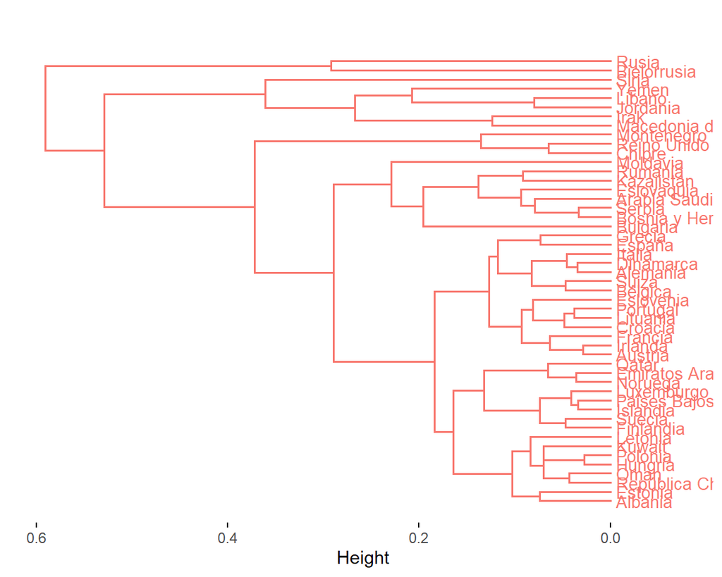

```
character(0)
```